# Benchmarks con modello Seasonal Naive

In questo notebook vengono effettuati i due approcci basici per il calcolo delle serie gerarchie della competition. Nello specifico sono analizzati i metodi Top-Down e Bottom-up utilizzando come modello di base il Seasonal Naive con parametro frequency = 7.

```r
source("models.R")
source("utils.R")
sales_train_validation <- read.csv("data/sales_train_validation.csv",stringsAsFactors = FALSE)
df_sales <-data.frame(sales_train_validation)
rm(sales_train_validation)
calendar <-read.csv("data/calendar.csv",stringsAsFactors = FALSE)
df_calendar <-data.frame(calendar)
rm(calendar)
sell_prices<- read.csv("data/sell_prices.csv",stringsAsFactors = FALSE)
df_sell_prices <-data.frame(sell_prices)
rm(sell_prices)
```

Per ottenere la metrica WRMSSE della competition è necessario generare i pesi per ogni livello della gerarchia come viene riportato nella guida.

La formuala del WRMSSE è la seguente:

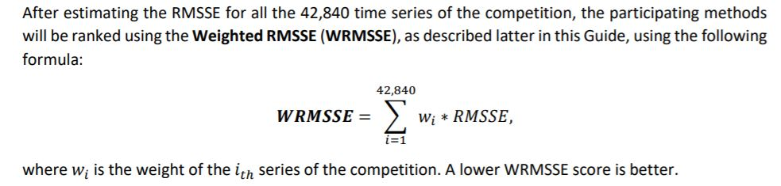

```r
##calcola tutti i pesi w per la metrica WRMSSE( per tutti e 12 i livelli)
list_weights<-compute_weights(df_sales, df_sell_prices, df_calendar)
```

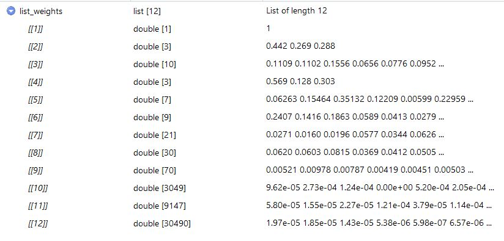

Quindi ottengo dal dataset delle vendite tutte le serie di basso livello:

```r
#riorganizzo il dataframe per applicare il forecast
df_sales$item_store_id <- apply( df_sales[ ,c('item_id','store_id')],1,paste,collapse = "_")
df_sales <- df_sales[,7:ncol(df_sales)]
ts_sales <-data.frame(t(df_sales))
colnames(ts_sales)<-df_sales[,'item_store_id']
ts_sales<-data.frame(ts_sales[1:1913,])
#to retransfrom all values in integer
ts_sales <- data.frame(lapply(ts_sales, function(x) as.numeric(as.character(x))))
head(ts_sales)
```

|  | HOBBIES_1_001_CA_1 | HOBBIES_1_002_CA_1 | HOBBIES_1_003_CA_1 | HOBBIES_1_004_CA_1 | HOBBIES_1_005_CA_1 | HOBBIES_1_006_CA_1 | HOBBIES_1_007_CA_1 | HOBBIES_1_008_CA_1 | HOBBIES_1_009_CA_1 | HOBBIES_1_010_CA_1 | HOBBIES_1_011_CA_1 | HOBBIES_1_012_CA_1 | HOBBIES_1_013_CA_1 | HOBBIES_1_014_CA_1 | HOBBIES_1_015_CA_1 | HOBBIES_1_016_CA_1 | HOBBIES_1_017_CA_1 | HOBBIES_1_018_CA_1 | HOBBIES_1_019_CA_1 | HOBBIES_1_020_CA_1 | HOBBIES_1_021_CA_1 | HOBBIES_1_022_CA_1 | HOBBIES_1_023_CA_1 | HOBBIES_1_024_CA_1 | HOBBIES_1_025_CA_1 | HOBBIES_1_026_CA_1 | HOBBIES_1_027_CA_1 | HOBBIES_1_028_CA_1 | HOBBIES_1_029_CA_1 | … |
| --- | --- | --- | --- | --- | --- | --- | --- | --- | --- | --- | --- | --- | --- | --- | --- | --- | --- | --- | --- | --- | --- | --- | --- | --- | --- | --- | --- | --- | --- | --- |
| 1 | 0 | 0 | 0 | 0 | 0 | 0 | 0 | 12 | 2 | 0 | 0 | 0 | 0 | 0 | 4 | 5 | 0 | 0 | 0 | 0 | 0 | 2 | 2 | 0 | 0 | 0 | 0 | 0 | 2 | … |
| 2 | 0 | 0 | 0 | 0 | 0 | 0 | 0 | 15 | 0 | 0 | 0 | 2 | 0 | 0 | 0 | 1 | 0 | 0 | 0 | 0 | 0 | 1 | 1 | 0 | 0 | 0 | 0 | 0 | 0 | … |
| 3 | 0 | 0 | 0 | 0 | 0 | 0 | 0 | 0 | 7 | 1 | 0 | 0 | 0 | 0 | 0 | 3 | 0 | 0 | 0 | 0 | 0 | 1 | 0 | 0 | 0 | 0 | 0 | 0 | 3 | … |
| 4 | 0 | 0 | 0 | 0 | 0 | 0 | 0 | 0 | 3 | 0 | 0 | 0 | 0 | 0 | 5 | 0 | 0 | 0 | 0 | 0 | 0 | 1 | 0 | 0 | 0 | 0 | 0 | 0 | 0 | … |
| 5 | 0 | 0 | 0 | 0 | 0 | 0 | 0 | 0 | 0 | 0 | 0 | 0 | 0 | 0 | 0 | 15 | 0 | 0 | 0 | 0 | 0 | 0 | 2 | 0 | 0 | 0 | 0 | 1 | 0 | … |
| 6 | 0 | 0 | 0 | 0 | 0 | 0 | 0 | 4 | 2 | 0 | 0 | 0 | 0 | 0 | 0 | 32 | 0 | 0 | 0 | 0 | 0 | 0 | 1 | 0 | 0 | 0 | 0 | 2 | 2 | … |

Prima di tutto creo la gerarchia con tutte le seire cosi come indicato:

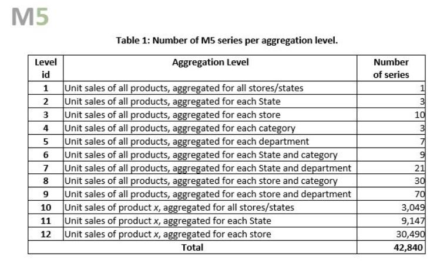

```r
#generate hierarchy
hierarchy<-compute_hierarchy(ts_sales, period=1:1913)
```

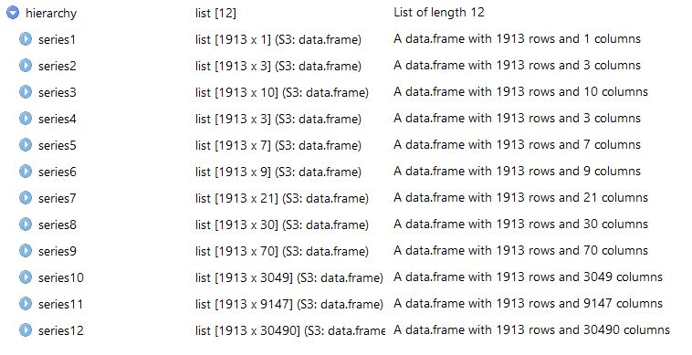

# Top Down

Il primo approccio valutato è quello top down. La disaggregazione dal totale viene fatta utilizando delle proporzioni.In partiolare in questo caso sono state utilizzate le **average historical proportions**. Dunque genero la lista di proportionals, una per ogni livello della gerarchia:

```r
#Average historical proportions
list_proportions<-compute_proportions(hierarchy)
```

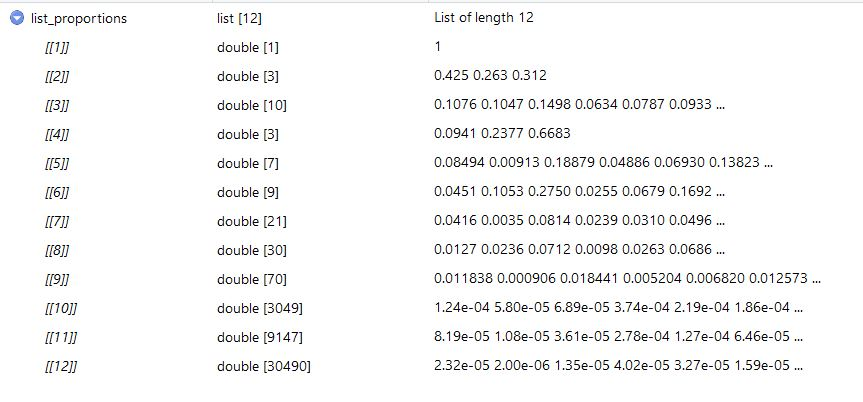

Faccio poi il forecast della serie top level utilizzando come modello il seasonal naive:

```r
top_level       <- data.frame(hierarchy$series1)
names(top_level)<- c("Y")
#faccio il forecast della serie top-level(totale)
output <- fit_snaive(top_level, horizon=28, frequency=7,"Y")
par(mfrow=c(1, 1))
plot(output$actual, type="l",ylab="sales", xlab="day", main=" Top-level series predicted with snaive (last 28 days)")
lines(output$predicted, col="red")
```

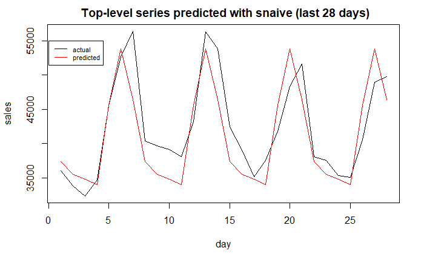

```r
legend(0,55000,legend = c("actual","predicted"), col = c("black","red"), lty = 1:1, cex = 0.7)
```

Infine genero le serie dei livelli successivi disaggregando e calcolo l’RMSSE relativo ad ognuna:

```r
top_level_predicted       <-data.frame(output$predicted)
names(top_level_predicted)<- c("Y")
#calcolo gli rmsse per ogni livello
list_rmsse <-compute_topdown_rmsse(hierarchy, top_level_predicted, list_proportions)
```

```
[1] "series_size 1"
[1] "series_size 3"
[1] "series_size 10"
[1] "series_size 3"
[1] "series_size 7"
[1] "series_size 9"
[1] "series_size 21"
[1] "series_size 30"
[1] "series_size 70"
[1] "series_size 3049"
[1] "series_size 9147"
[1] "series_size 30490"
```

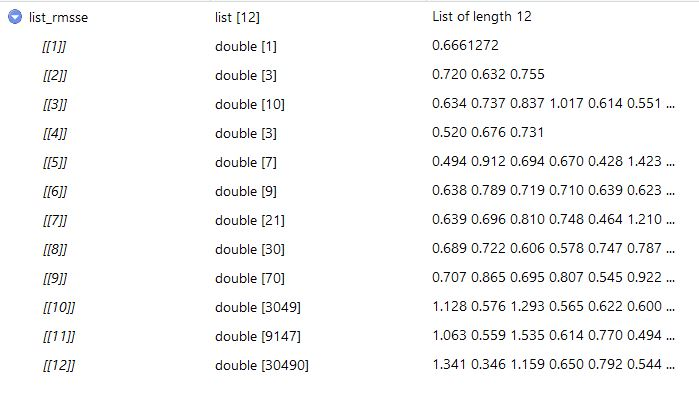

Quindi il WRMSSE ottenuto è:

```r
compute_wrmsse( list_weights, list_rmsse)
```

```
[1] 0.762707
```

## Bottom-up

Con l’approccio bottom-up invece faccio il forecast di tutte le serie di basso livello e poi aggrego fino ad arrivare alla radice.

Quidni parto con il forecast delle 30490 serie del livello 12 utilizzando il modello seasonal naive:

```r
#level 12 (bottom)
#30490 series
output<- compute_all_forecasts(ts_sales, horizon=28, frequency=7, fit_snaive)
```

E poi aggrego livello per livello fino ad arrivare al totale:

```r
#level11
#9147 series
# HOBBIES_1_001_CA_1 -> HOBBIES_1_001_CA
result11 <-map(output$df_predicted, ts_sales, gsub, '.{2}$')
grouped11<-aggregate_level(result11$map_predicted, result11$map_actual)
errors11 <-compute_rmsse(grouped11$agg_predicted, grouped11$agg_actual, horizon=28)
#level10
#3049 series
# HOBBIES_1_001_CA -> HOBBIES_1_001
result10 <-map(grouped11$agg_predicted, grouped11$agg_actual, gsub, '.{3}$')
grouped10<-aggregate_level(result10$map_predicted, result10$map_actual)
errors10 <-compute_rmsse(grouped10$agg_predicted, grouped10$agg_actual, horizon=28)
#level9
# 70 series
# HOBBIES_1_001_CA_1 -> HOBBIES_1_CA_1
result9 <-map(output$df_predicted, ts_sales, gsub, "_\\d{3}")
grouped9<-aggregate_level(result9$map_predicted, result9$map_actual)
errors9 <-compute_rmsse(grouped9$agg_predicted, grouped9$agg_actual, horizon=28)
#level8
# 30 series
# HOBBIES_1_001_CA_1 -> HOBBIES_CA_1
result8 <-map(output$df_predicted, ts_sales, gsub, "_\\d+_\\d+")
grouped8<-aggregate_level(result8$map_predicted, result8$map_actual)
errors8 <-compute_rmsse(grouped8$agg_predicted, grouped8$agg_actual, horizon=28)
#level7
# 21 series
# HOBBIES_1_001_CA -> HOBBIES_1_CA
result7 <-map(grouped11$agg_predicted, grouped11$agg_actual, gsub, "_\\d{3}")
grouped7<-aggregate_level(result7$map_predicted, result7$map_actual)
errors7 <-compute_rmsse(grouped7$agg_predicted, grouped7$agg_actual, horizon=28)
#level6
# 9 series
# HOBBIES_1_001_CA -> HOBBIES_CA
result6 <-map(grouped11$agg_predicted, grouped11$agg_actual, gsub, "_\\d+_\\d+")
grouped6<-aggregate_level(result6$map_predicted, result6$map_actual)
errors6 <-compute_rmsse(grouped6$agg_predicted, grouped6$agg_actual, horizon=28)
#level5
# 7 series
# HOBBIES_1_001_CA -> HOBBIES_1
result5 <-map(grouped11$agg_predicted, grouped11$agg_actual, gsub, ".{7}$")
grouped5<-aggregate_level(result5$map_predicted, result5$map_actual)
errors5 <-compute_rmsse(grouped5$agg_predicted, grouped5$agg_actual, horizon=28)
#level4
# 3 series
# HOBBIES_1 -> HOBBIES
result4 <-map(grouped5$agg_predicted, grouped5$agg_actual, gsub, '.{2}$')
grouped4<-aggregate_level(result4$map_predicted, result4$map_actual)
errors4 <-compute_rmsse(grouped4$agg_predicted, grouped4$agg_actual, horizon=28)
#level3
# 10 series
# HOBBIES_1_CA_1 -> CA_1
result3 <-map(grouped9$agg_predicted, grouped9$agg_actual, gsub,"^.*?\\_\\d_")
grouped3<-aggregate_level(result3$map_predicted, result3$map_actual)
errors3 <-compute_rmsse(grouped3$agg_predicted, grouped3$agg_actual, horizon=28)
#level2
# 3 series
# CA_1 -> CA
result2 <-map(grouped3$agg_predicted, grouped3$agg_actual, gsub, '.{2}$')
grouped2<-aggregate_level(result2$map_predicted, result2$map_actual)
errors2 <-compute_rmsse(grouped2$agg_predicted, grouped2$agg_actual, horizon=28)
#level1 (top)
#grouped1<-list()
agg_predicted1<-data.frame(apply(grouped2$agg_predicted,1,sum))
agg_actual1   <-data.frame(apply(grouped2$agg_actual,1,sum))
names(agg_predicted1) <- c("Y")
names(agg_actual1)    <- c("Y")
errors1 <-compute_rmsse(agg_predicted1, agg_actual1, horizon=28)
```

Quindi calcolo il WRMSSE:

```r
list_rmsse <-list(errors1,errors2,errors3,errors4,errors5,errors6,errors7,errors8,errors9, errors10, errors11,output$errors)
compute_wrmsse( list_weights, list_rmsse)
```

```
[1] 0.9695381
```

I valori di WRMSSE ottenuti sono quindi

- approccio Top-down : 0.762707
- approccio Bottom-up : 0.9695381

Attualmente nella Leaderboard il primo in classifica ha uno score di 0.46850